# Week 7 Online Lecture - Maps Part 2

Author

Linnea Nordli

## Install packages

```r
install.packages(c(
  "maptiles",      # download tile basemaps (satellite, street, terrain)
  "tidyterra",     # plot terra rasters in ggplot2
  "leaflet",       # interactive HTML maps
  "tidygeocoder",  # free geocoding (OpenStreetMap / Census)
  "ggspatial"      # scale bars and north arrows
  ))
```

## Load libraries

```r
library(tidyverse)
library(here)
library(sf)
library(maptiles)
library(tidyterra)
library(leaflet)
library(tidygeocoder)
library(ggspatial)
```

## Import Data

```r
ChemData <- read_csv(here("Week_07", "data", "chemicaldata_maunalua.csv"))

glimpse(ChemData)
```

```
Rows: 23
Columns: 15
$ Waypoint    <dbl> 1, 2, 3, 4, 5, 6, 7, 8, 9, 10, 11, 12, 13, 14, 15, 16, 17,…
$ Zone        <chr> "Transition", "Transition", "Transition", "Transition", "D…
$ Lat         <dbl> 21.27531, 21.27523, 21.27504, 21.27449, 21.27503, 21.27485…
$ Long        <dbl> -157.7618, -157.7627, -157.7633, -157.7640, -157.7617, -15…
$ Site        <chr> "W", "W", "W", "W", "W", "W", "W", "W", "W", "W", "W", "W"…
$ Season      <chr> "SPRING", "SPRING", "SPRING", "SPRING", "SPRING", "SPRING"…
$ Tide_time   <chr> "Low_Day", "Low_Day", "Low_Day", "Low_Day", "Low_Day", "Lo…
$ Temp_in     <dbl> 23.75506, 23.53256, 22.63450, 24.01982, 23.26102, 24.00517…
$ Salinity    <dbl> 27.74029, 30.61192, 28.37008, 32.82124, 29.12293, 34.02018…
$ Phosphate   <dbl> 0.54, 0.36, 0.50, 0.25, 0.50, 0.13, 0.28, 0.15, 0.23, 0.11…
$ Silicate    <dbl> 157.93, 92.59, 143.60, 42.32, 126.47, 15.04, 56.31, 23.10,…
$ NN          <dbl> 7.92, 3.37, 7.29, 0.79, 7.45, 0.46, 1.59, 0.34, 1.91, 0.25…
$ pH          <dbl> 7.909, 7.965, 8.023, 7.995, 8.005, 8.019, 8.003, 7.978, 7.…
$ TA          <dbl> 2161.482, 2145.828, 2272.391, 2219.583, 2151.826, 2216.758…
$ percent_sgd <dbl> 20.4043928, 11.9625323, 18.5529716, 5.4677003, 16.3397933,…
```

## Tile and satellite basemaps with {maptiles}

{maptiles} downloads satellite and street map tiles from free public providers directly into R. Maps are made of thousands of pixel tiles stitched together. Tiles are organized by **zoom level** and **grid position**.

- At zoom 1, a handful of tiles covers the whole world
- At zoom 17, thousands of tiles cover a single neighborhood
- maptiles figures out which tiles you need, downloads them, and stitches them into one image

### Step 1 - Define Interest Area

get_tiles() needs a bounding box, a rectable defined by corner coordinates, to know what area to download

```r
# Define a bounding box around Wailupe, Oahu
# xmin/xmax = westmost/eastmost longitude
# ymin/ymax = southernmost/northernmost latitude
wailupe_bbox <- st_as_sfc( # converts it to a spatial geometric object
  st_bbox(c(xmin = -157.772, ymin = 21.267,
            xmax = -157.752, ymax = 21.281),
          crs = 4326) # crs = 4326 means WGS84 — the lat/lon system your GPS uses
)
```

### Step 2 - Download the Tiles

```r
tiles_satellite <- get_tiles( # creates a SpatRaster (grid of pixels) from {terra} package
  wailupe_bbox,               # the area to download
  provider = "Esri.WorldImagery", # which tile source to use
  zoom = 16,                  # level of detail (3 = continent, 20 = building)
  crop = TRUE,                # clip to our exact bbox (vs. slightly larger)
  cachedir = here("Week_07", "Data", "tiles_cache") # save tiles to disk
)
```

### Step 3 - Plot

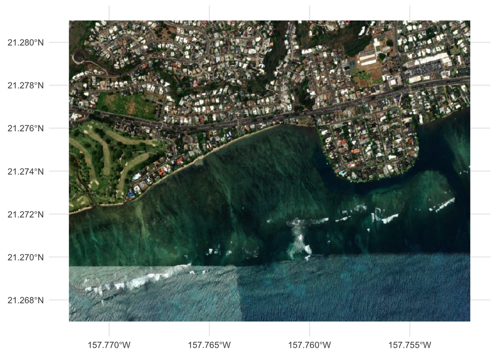

```r
# geom_spatraster_rgb() is from {tidyterra}
# It reads the 3 color layers and renders them as a photo
ggplot() +
  geom_spatraster_rgb(data = tiles_satellite) +
  coord_sf(crs = 4326) +
  theme_minimal()
```

### Different Tile Providers

Just change the *provider* string in get_tiles — all are free with no API key:

| **Provider String** | **Style** |
| --- | --- |
| “Esri.WorldImagery” | Satellite |
| “OpenStreetMap” | Street map |
| “CartoDB.Positron” | Minimal/clean |
| “Esri.WorldStreetMap” | ESRI street |
| “Esri.WorldTerrain” | Shaded terrain |

### Derive Bbox from your data

Instead of hard-coding coordinates, generate the bounding box directly from your data:

#### Step 1: convert your data frame to an sf object

```r
ChemData_sf <- st_as_sf(ChemData,
                         coords = c("Long", "Lat"), # coords tells sf which columns hold longitude and latitude
                         crs = 4326)
```

#### Step: 2: get the bounding box and add a small buffer

```r
bbox_chem <- st_bbox(ChemData_sf) + c(-0.004, -0.004, 0.004, 0.004) # the + c(...) pads all four sides by ~0.4 km so points aren't at the edge
```

#### Step 3: download tiles for that extent

```r
Map_satellite <- get_tiles(
  st_as_sfc(bbox_chem),
  provider = "Esri.WorldImagery",
  zoom = 15,
  crop = TRUE,
  cachedir = here("Week_07", "Data", "tiles_cache")
)
```

#### Step 4: Overlay Data Point

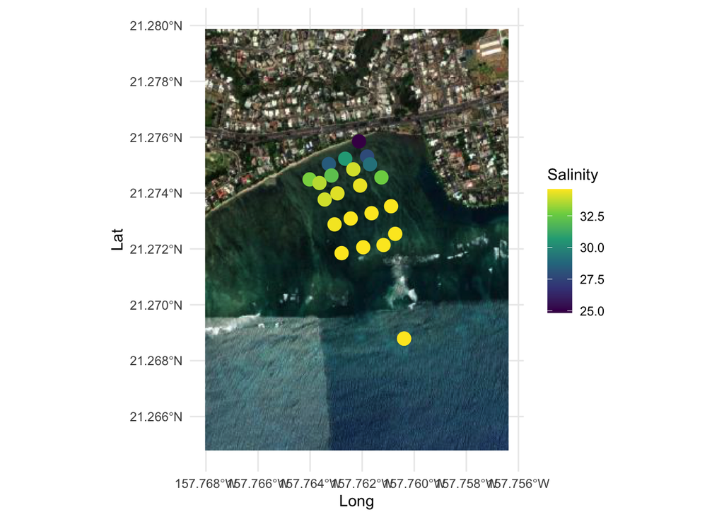

```r
ggplot() +
  geom_spatraster_rgb(data = Map_satellite) +
  geom_point(data = ChemData,
             aes(x = Long, y = Lat,
                 color = Salinity),
             size = 4) +
  scale_color_viridis_c() +
  coord_sf(crs = 4326) +
  theme_minimal()
```

## Overlaying data + annotations with {ggspatial}

{ggspatial} provides two annotation functions that are spatial-aware — they calculate real-world distances and magnetic north automatically.

### Add a Scale Bar and North Arrow

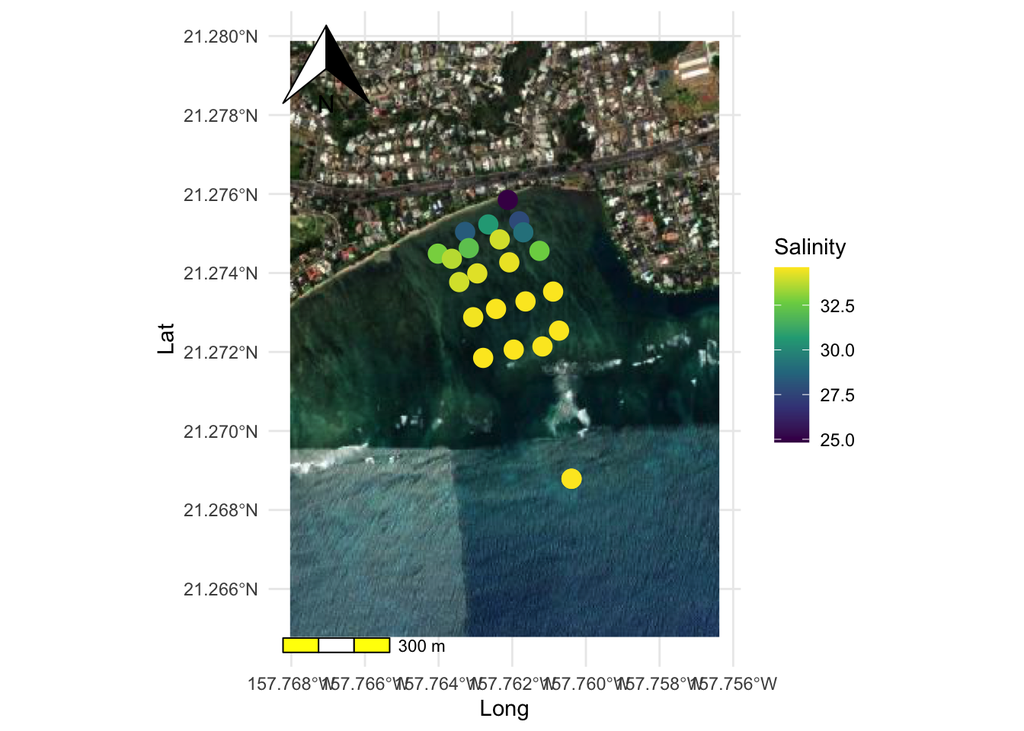

```r
ggplot() +
  geom_spatraster_rgb(data = Map_satellite) +
  geom_point(data = ChemData,
             aes(x = Long, y = Lat,
                 color = Salinity),
             size = 4) +
  scale_color_viridis_c() +
  annotation_scale(           # scale bar
    location = "bl",          # bl = bottom-left
    bar_cols = c("yellow", "white")) +
  annotation_north_arrow(     # north arrow
    location = "tl") +        # tl = top-left
  coord_sf(crs = 4326) +
  theme_minimal()
```

### Polish and Save

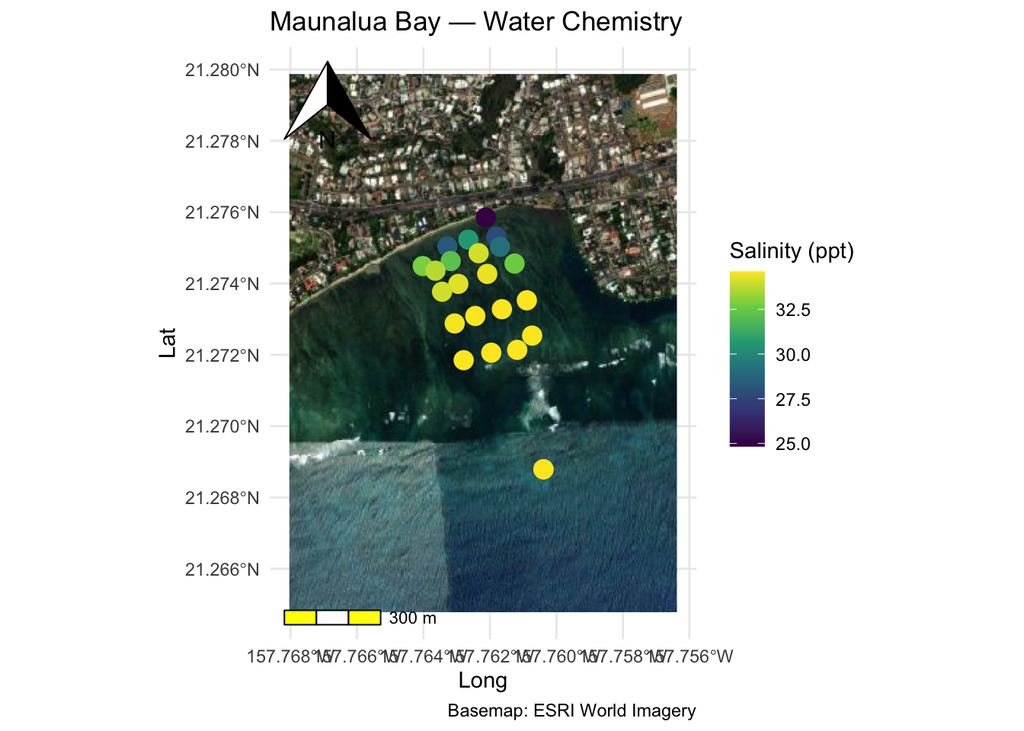

```r
ggplot() +
  geom_spatraster_rgb(data = Map_satellite) +
  geom_point(data = ChemData,
             aes(x = Long, y = Lat, color = Salinity),
             size = 4) +
  scale_color_viridis_c(name = "Salinity (ppt)") +
  annotation_scale(location = "bl",
                   bar_cols = c("yellow", "white")) +
  annotation_north_arrow(location = "tl") +
  coord_sf(crs = 4326) +
  labs(title = "Maunalua Bay — Water Chemistry", # add labels and source
       caption = "Basemap: ESRI World Imagery") +
  theme_minimal()
```

```r
ggsave(here("Week_07", "Outputs", "maunalua_map.pdf"), width = 8, height = 6)
```

## Interactive Maps with {leaflet}

Static maps are great for publications. Interactive maps let you zoom, pan, and click on your data — and embed directly in HTML documents. {leaflet} builds maps by piping layers together with |> — similar in concept to ggplot’s +, but using pipes instead.

```r
leaflet() |>                       # 1. create the map widget
  addProviderTiles(...) |>         # 2. add a basemap tile layer
  addCircleMarkers(...) |>         # 3. add your data as markers
  addLegend(...)                   # 4. add a color legend
```

The result is an interactive HTML widget — it works in RStudio, Quarto HTML, and any web browser.

### Creating a leaflet map

setView() centers the map on a specific location. lng and lat are the coordinates, and zoom works exactly like in {maptiles}. From here you can zoom in and out and move aroud.

```r
leaflet() |>
  addProviderTiles(providers$Esri.WorldImagery) |>
  setView(lng = -157.762, lat = 21.274, zoom = 14)
```

[interactive chart not shown]

#### The ~ Formula Notation

In leaflet, column names are written with a ~ prefix.

- ~Long means “use the Long column from the data frame”
- It is leaflet’s equivalent of aes(x = Long) in ggplot
- You will see ~ anywhere leaflet needs to reference a column

```r
addCircleMarkers(lng = ~Long, lat = ~Lat, color = ~pal(Salinity))
```

#### Add color palette

Leaflet needs a color function that converts numeric values to hex colors. colorNumeric() creates one:

```r
# colorNumeric() returns a FUNCTION, not a color vector
pal <- colorNumeric(
  palette = "viridis",            # any RColorBrewer or viridis palette name
  domain = ChemData$Salinity      # the full range of values to map
)

# Use it by calling pal(value) — it returns a hex color
pal(30)  # what color does salinity = 30 get?
```

```
[1] "#1F978B"
```

#### Add Data Points with Color

```r
leaflet(ChemData) |>           # pass data frame here
  addProviderTiles(providers$Esri.WorldImagery) |>
  addCircleMarkers(
    lng = ~Long, lat = ~Lat,   # which columns are coordinates
    color = ~pal(Salinity),    # apply our color function to Salinity
    radius = 6, # size of circle
    fillOpacity = 0.9,
    popup = ~paste("Salinity:", Salinity, "ppt",  # CLICK a point to see this
                   "<br>Site:", Site)) |> # line break inside popups between salinity and site
  addLegend(
    pal = pal,                 # the same color function
    values = ~Salinity,        # which column drives the legend
    title = "Salinity (ppt)",
    position = "bottomright")
```

[interactive chart not shown]

##### label vs popup

```r
addCircleMarkers(
  label = ~Site)
```

## Geocoding with {tidygeocoder}

Geocoding = converting a place name or address into latitude and longitude coordinates.

- Geocoding requires an internet connection and results depend on the service’s database. OSM is very good for well-known places but may fail on obscure locations or unusual search strings.
- You know *where* you want to map, but not the exact coordinates
- Geocoding services look up addresses and place names in a database and return lat/lon
- {tidygeocoder} does this for free using:
  - **OpenStreetMap** (method = “osm”) — best for landmarks and place names worldwide
  - **US Census** (method = “census”) — best for US street addresses

### geo() — Convert a Place Name to Coordinates

geo() geocodes a single location string and returns a one-row tibble:

```r
geo("University of Hawaii at Manoa", method = "osm")
```

```
# A tibble: 1 × 3
  address                         lat  long
  <chr>                         <dbl> <dbl>
1 University of Hawaii at Manoa  21.3 -158.
```

If a location returns NA, try a more specific search string — add the city, state, or country. OSM often needs more context for landmarks that share names across locations.Google what does the street map call it: Pearl Harbor National Memorial, Hawaii

```r
geo("Pearl Harbor, Oahu, Hawaii", method = "osm")
```

```
# A tibble: 1 × 3
  address                      lat  long
  <chr>                      <dbl> <dbl>
1 Pearl Harbor, Oahu, Hawaii    NA    NA
```

### geocode() — Geocode a Data Frame

**geocode()** (note: no “r”) operates on a data frame and adds lat/lon columns:

```r
oahu_sites <- tribble(
  ~place,
  "University of Hawaii at Manoa",
  "Honolulu International Airport",
  "Pearl Harbor National Memorial, Hawaii",
  "Diamond Head State Monument, Hawaii"
)

oahu_geocoded <- oahu_sites |> # creates a df
  geocode(place, method = "osm") # geocode the 'place' column
```

### Map Geocoded Locations

```r
leaflet(oahu_geocoded) |>
  addProviderTiles(providers$Esri.WorldImagery) |>
  addMarkers(
    lng = ~long, lat = ~lat,   # tidygeocoder always returns 'lat' and 'long'
    label = ~place)            # label to hover over to see place name
```

[interactive chart not shown]